# homework 3: logistic regression

- homework is due in Dropbox on Avenue on **Weds 26 September**.
- your homework should be saved as R code with comments (`.R`), R markdown (`.Rmd`), or Sweave (`.Rnw`)
- **none of the following functions should appear in your solution**:
  - `setwd()`
  - `rm(list=ls())`
  - `attach()`
- the TA or I should be able run your code from scratch without any problems.

## logistic regression on beetles

1. create a plot displaying the data; use `stat_sum` (with `ggplot`) or `plotrix::sizeplot()` so that the graph shows the number of data values at each point. It’s up to you whether to distinguish between `series="I"` and `series="II"` in the data.

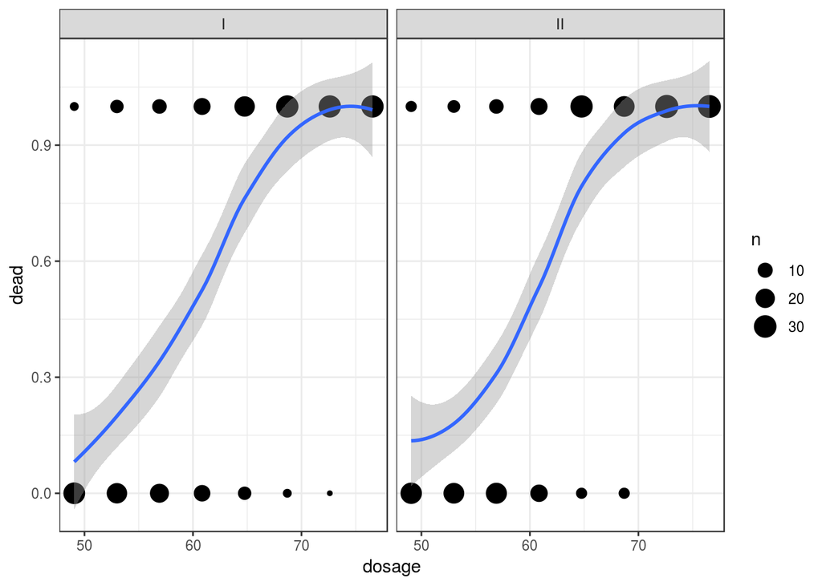

```r
dd <- read.csv("../data/beetle3.csv")
library(ggplot2); theme_set(theme_bw())
ggplot(dd,aes(dosage,dead))+stat_sum()+facet_wrap(~series)+
    geom_smooth()
```

Or:

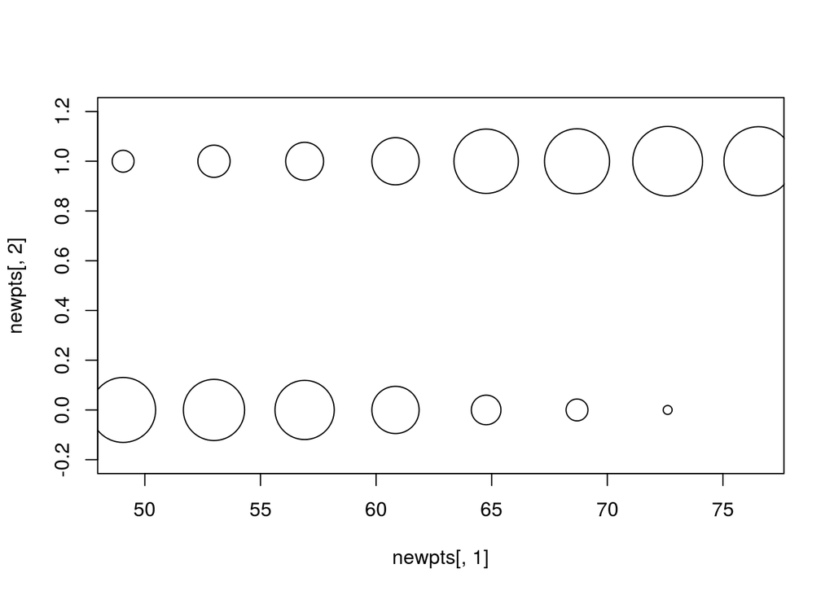

```r
library(plotrix)
with(dd,sizeplot(dosage,dead,ylim=c(-0.2,1.2)))
```

2. use `aggregate` (base R) or `group_by` + `summarise` (`dplyr`) to compute the proportion killed for each unique dosage value/series combination. Optionally, add another column with the total number of individuals for each dosage value/series combination.

```r
## with dplyr:
dd2 <- (dd
    %>% group_by(series,dosage)
    %>% summarise(tot=n(),prop=mean(dead))
)

## with aggregate:
## (there are various ways to do it but I prefer the formula interface
dd2B <- aggregate(dead~dosage+series, FUN=mean, data=dd)
##  to add another column:
dd2B <- aggregate(dead~dosage+series,
                  FUN=function(x) c(prop=mean(x), tot=length(x)),
                  data=dd)
## collapse matrix elements
dd2B <- do.call(data.frame, dd2B)
```

3. Create a plot showing these aggregated values; add a smooth line showing the general trend. If you’re feeling ambitious, make the size of the points proportional to the total number of individuals.

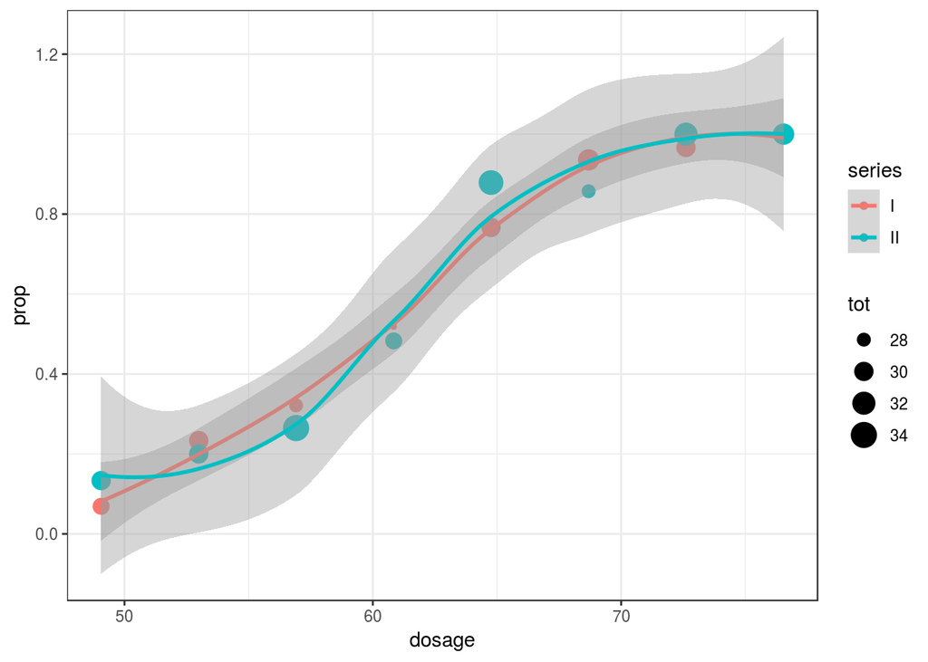

```r
ggplot(dd2,aes(dosage,prop,colour=series))+geom_point(aes(size=tot))+
    geom_smooth(aes(weight=tot))
```

4. Fit a logistic model including the interaction of the predictors `series` and `log10(dose)` to the **original** (disaggregated) data.

```r
g1 <- glm(dead ~ series*log10(dosage), data=dd, family=binomial)
```

5. Explain the meaning of the four parameters in words, as they relate to the expected survival, the effects of dose on survival, and the differences in these quantities between series.

*Answers will depend on whether you used treatment or sum-to-zero contrasts*

6. Test the null hypothesis that the two series have identical dose-response curves. Explain whether you are using a Wald test or a likelihood ratio test, and what that means. Is there evidence that the intercepts differ, the slopes, or neither?

Likelihood ratio test of combination of intercepts and slopes:

```r
g0 <- update(g1, . ~ log10(dosage))
anova(g0, g1, test="Chisq")
```

```
## Analysis of Deviance Table
##
## Model 1: dead ~ log10(dosage)
## Model 2: dead ~ series * log10(dosage)
##   Resid. Df Resid. Dev Df   Deviance Pr(>Chi)
## 1       479     372.46
## 2       477     372.46  2 0.00039563   0.9998
```

(i.e. no evidence that either slopes or intercepts differ)

Wald tests of differences in intercept alone (`seriesII`), differences in slope alone (`seriesII:log10(dosage)`)

```r
printCoefmat(coef(summary(g1))[c("seriesII","seriesII:log10(dosage)"),])
```

```
##                        Estimate Std. Error z value Pr(>|z|)
## seriesII               -0.20470   10.36265 -0.0198   0.9842
## seriesII:log10(dosage)  0.11537    5.82493  0.0198   0.9842
```

7. Fit a model that uses only `log10(dose)`, ignoring `series`.

We already did this, more or less:

```r
glm(dead ~ log10(dosage), data=dd, family=binomial)
```

```
##
## Call:  glm(formula = dead ~ log10(dosage), family = binomial, data = dd)
##
## Coefficients:
##   (Intercept)  log10(dosage)
##        -60.72          34.27
##
## Degrees of Freedom: 480 Total (i.e. Null);  479 Residual
## Null Deviance:       645.4
## Residual Deviance: 372.5     AIC: 376.5
```

8. Compute and compare the Wald, likelihood profile, and bootstrap confidence intervals for the dose effect.

```r
(c1 <- stats::confint.default(g0)["log10(dosage)",])
```

```
##    2.5 %   97.5 %
## 28.56520 39.98054
```

```r
(c2 <- suppressMessages(confint(g0)["log10(dosage)",]))
```

```
##    2.5 %   97.5 %
## 28.85651 40.30322
```

```r
## suppressMessages() to get rid of "Waiting for profiling to be done ..."
## not identical, but **very** close
c1-c2
```

```
##      2.5 %     97.5 %
## -0.2913014 -0.3226809
```

Bootstrap:

```r
bootfun0 <- function() {
    bootdat <- dd[sample(nrow(dd),replace=TRUE),]
    gb <- update(g0, data=bootdat)
    b1 <- coef(gb)["log10(dosage)"]
    return(b1)
}
set.seed(101)
bootvals0 <- replicate(1000,bootfun0())
(boot_ci0 <- quantile(bootvals0,c(0.025,0.975)))
```

```
##     2.5%    97.5%
## 29.23505 40.74178
```

Also very similar (bootstrap CIs have an extra stochastic component, as well; we might get slightly different answers if we ran it all with a different random-number seed)

9. Compute and display quantile residual-based diagnostics: what do you conclude?

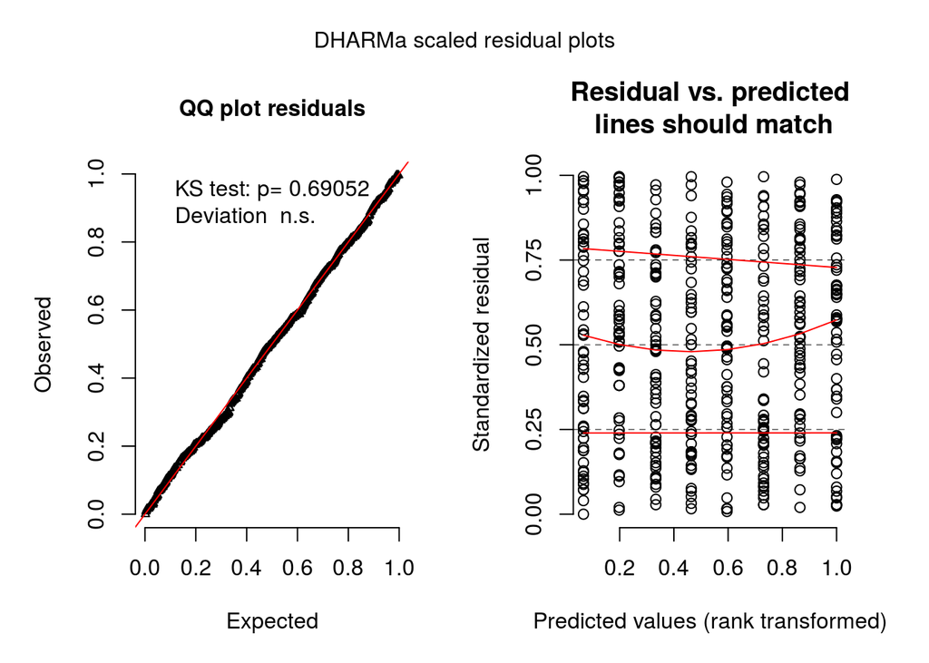

```r
rr <- DHARMa::simulateResiduals(g0, plot=TRUE)
```

Plot residuals look more or less perfect (which they kind of have to be, since the Bernoulli conditional distribution is necessarily true); quantile values (red vs dotted black lines) look good, suggesting little bias. (I didn’t use `pch="."` here, not really useful unless we have a very large data set).

10. Compute predicted survival probabilities and confidence intervals for the minimum, mean, and maximum log10(dose)

```r
pframe <- with(dd2,
               data.frame(dosage=c(min(dosage),mean(dosage),max(dosage))))
## could use 10^mean(log10(dosage)) for central value as well
pp <- predict(g0, newdata=pframe, se.fit=TRUE)
pframe$prob <- plogis(pp$fit)
pframe$lwr <- plogis(pp$fit-1.96*pp$se.fit)
pframe$upr <- plogis(pp$fit+1.96*pp$se.fit)
```

11. The LD50 (dose that is expected to kill 50% of individuals) is defined as the point where the log-odds of survival are equal to zero, i.e. x0.5=−β0/β1 . Compute the LD50 based on your fit.

```r
LD50 <- with(as.list(coef(g0)), -`(Intercept)`/`log10(dosage)`)
```

12. Compute confidence intervals for the LD50 using (1) the delta method and (2) bootstrapping.

Delta method:

```r
## b0 + b1*x = 0 -> x = -b0/b1
b0 <- coef(g0)[["(Intercept)"]]
b1 <- coef(g0)[["log10(dosage)"]]
## derivs: c(-1/b1, b0/b1^2)
grad <- c(-1/b1,b0/b1^2)
(delta_sd <- c(sqrt(grad %*% vcov(g0) %*% grad)))
```

```
## [1] 0.003857782
```

```r
## c() converts result from a matrix to a (length-1) vector
(delta_ci <- (-b0/b1) + 1.96*c(-1,1)*delta_sd)
```

```
## [1] 1.764156 1.779278
```

Lazy method:

```r
library(emdbook)
sqrt(deltavar(-b0/b1,meanval=c(b0=b0,b1=b1),Sigma=vcov(g0)))
```

```
## [1] 0.003857782
```

Bootstrap:

```r
bootfun <- function() {
    bootdat <- dd[sample(nrow(dd),replace=TRUE),]
    gb <- update(g0, data=bootdat)
    b0 <- coef(gb)[1]
    b1 <- coef(gb)[2]
    return(-b0/b1)
}
set.seed(101)
## a quick way to skip the for() loop
bootvals <- replicate(1000,bootfun())
(boot_ci <- quantile(bootvals,c(0.025,0.975)))
```

```
##     2.5%    97.5%
## 1.763499 1.779214
```

Delta-method and bootstrap results are very similar.